# Prelminary MLM Project

Effects of Education and Income on Cognitive Decline: A Multilevel Longitudinal Analysis

Sarah Hennessy and Amabel Jeon

2020-10-30

The data analytic scripts and supplemental materials for this project will be available at https://github.com/sarhen907/MLM-WLS.

# Introduction

Past research consistently revealed that increased age is associated with lower levels of cognitive performance. Although gradual decline is common in later life, the rate of cognitive decline varies substantially (Schaie, 1996; Zelinski & Stewart, 1998; Alley et al., 2007). Education is an important factor in such varying rates of cognitive decline. Longitudinal studies suggested that higher educational attainment is related to higher levels of cognitive performance in late life (Albert et al., 1995; Colsher and Wallace, 1991). However, some research reports the opposite, suggesting that higher education does not protect against cognitive decline (Christensen et al., 2001; Hultsch et al., 1998). To our knowledge, whether attaining higher levels of education leads to a delay in cognitive decline for older adults remains conflicted.

For this project, we aim to address the following questions: 1. Does educational attainment protect against cognitive decline later in life? 2. Does socioeconomic status, in childhood or adulthood, or sex, interact with the relationship between education and cognitive decline?

Our multilevel design is as follows: Level 1 is time point and Level 2 is subject. Level 1 variables include measures of cognition. Level 2 variables include id, sex (female or male), and SES (childhood and adulthood).

[figure not shown]

Three models will be fitted for each measure of cognition. Cognition at the first time point will be allowed to vary across participants as a random intercept. Models 1, 2, and 3 will assess the association between cognitive change across time and educational attainment (highest degree attained after hs), childhood SES (parents’ income comparison), or adult SES, respectively. We will also assess the interactions between these three predictors, as well as sex, on each outcome measure.

# Model Equations

For this iteration of the project, we will be focusing on a single outcome variable `simscore`, which refers to the similarities section of the Welschler’s Adult Intelligence Scale, a measure of verbal IQ. We will also only run a single model to assess the impact of sex and education on cognitive decline.

**Level 1 (within person):**

$$\text{simscore}_{ij} = \beta_{0j} + \beta_{1j} \text{year} + e_{ij}$$

**Level 2 (Between-person:)**
$$\begin{aligned}
\beta_{0j} & = \gamma_{00} + \gamma_{01} \text{edu}_{j} * \gamma_{02} \text{sex}_{j} + u_{0j} \\
\beta_{1j} & = \gamma_{10} + \gamma_{11} \text{edu}_{j} * \gamma_{02} \text{sex}_{j} + u_{0j} \\
\end{aligned}$$

# Models

## Coefficient Table

|  | simscore |  |
| --- | --- | --- |
| Predictors | Estimates | p |
| (Intercept) | 7.30 | **<0.001** |
| sex [Female] | 0.29 | **0.002** |
| edu [Associates] | 1.28 | **<0.001** |
| edu [Bachelors] | 1.72 | **<0.001** |
| edu [Masters] | 2.36 | **<0.001** |
| edu [Doctorate] | 2.52 | **<0.001** |
| year [2004] | -1.19 | **<0.001** |
| sex [Female] * edu [Associates] | 0.21 | 0.652 |
| sex [Female] * edu [Bachelors] | 0.05 | 0.793 |
| sex [Female] * edu [Masters] | -0.05 | 0.831 |
| sex [Female] * edu [Doctorate] | -0.61 | 0.279 |
| sex [Female] * year [2004] | -0.10 | 0.266 |
| edu [Associates] * year [2004] | -0.57 | 0.098 |
| edu [Bachelors] * year [2004] | -0.31 | **0.032** |
| edu [Masters] * year [2004] | -0.29 | 0.083 |
| edu [Doctorate] * year [2004] | -0.06 | 0.796 |
| (sex [Female] * edu [Associates]) * year [2004] | 0.88 | 0.060 |
| (sex [Female] * edu [Bachelors]) * year [2004] | 0.07 | 0.707 |
| (sex [Female] * edu [Masters]) * year [2004] | 0.30 | 0.239 |
| (sex [Female] * edu [Doctorate]) * year [2004] | 0.37 | 0.520 |
| Random Effects |  |  |
| σ<sup>2</sup> | 0.00 |  |
| τ<sub>00</sub> <sub>personid</sub> | 6.31 |  |
| τ<sub>11</sub> <sub>personid.year2004</sub> | 6.25 |  |
| ρ<sub>01</sub> <sub>personid</sub> | -0.63 |  |
| ICC | 1.00 |  |
| N <sub>personid</sub> | 4677 |  |
| Observations | 9135 |  |
| Marginal R<sup>2</sup> / Conditional R<sup>2</sup> | 0.184 / 1.000 |  |

## Plots

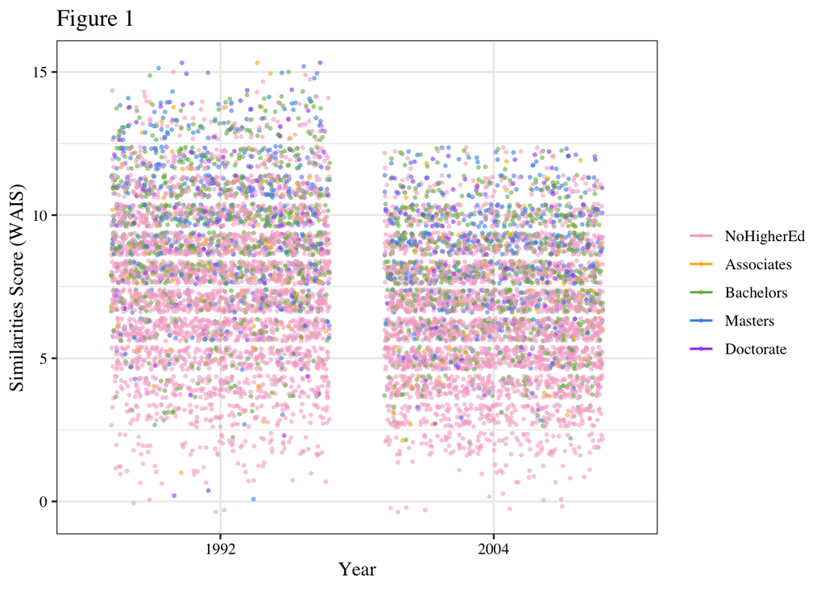

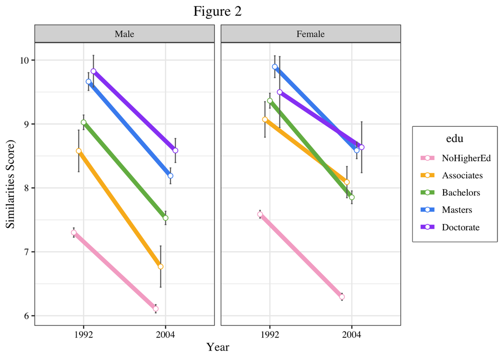